# CMPINF 2100 - Intro to Data Centric Computing FINAL PROJECT

# Initial Findings

In my exploratory analysis of the data (EDA), I found some notable trends:

- The following columns were missing data: `age`, `gender`, `peak_drivetime`, and `offpeak_drivetime`

```python
pitt_df.isna().sum()
```

```
accountid                0
age                   1793
gender                2778
distancemiles            0
direction                0
peak_drivetime         402
offpeak_drivetime      364
season                   0
purchase_month           0
purchase_dow             0
price_type               0
price_level              0
ticket_count             0
price_per_ticket         0
return_next_season       0
dtype: int64
```

- The `distancemiles` column was heavily skewed in distribution with extremely high counts of values 50 miles or less from the stadium

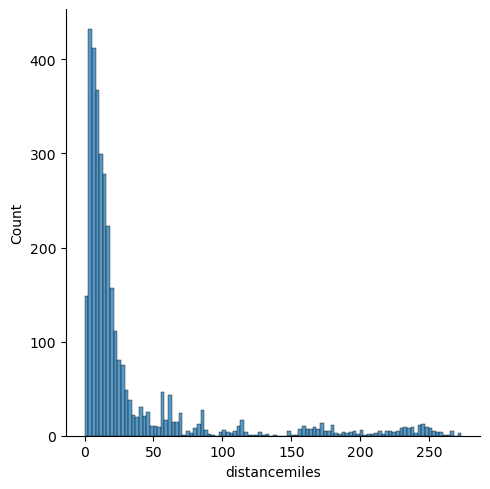

```python
sns.displot(data = pitt_df, x = 'distancemiles', kind = 'hist')

plt.show()
```

In order to better process this data point, the log transformation was applied in order to achieve a Guassian bell curve

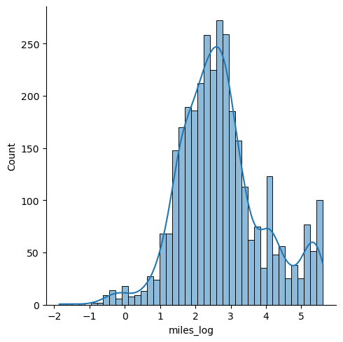

```python
pitt_df_clean = pitt_df.copy()
pitt_df_clean['miles_log'] = np.log(pitt_df_clean.distancemiles)
sns.displot(data = pitt_df_clean, x = 'miles_log', kind = 'hist', kde=True)
plt.show()
```

- While the `ticket_count` column was also heavily skewed, rather than perform transformations, the counts were binned by quantity of tickets purchased resulting in a new categorical datapoint called `lump_ticket_count`.

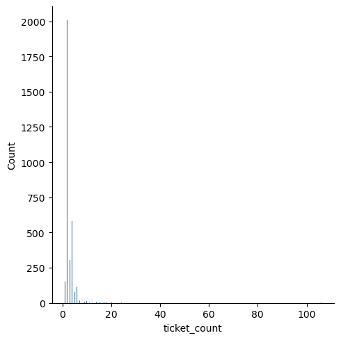

```python
sns.displot(data = pitt_df_clean, x = 'ticket_count', kind = 'hist')
plt.show()
```

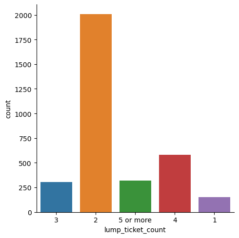

```python
pitt_df_clean['lump_ticket_count'] = np.where( pitt_df.ticket_count > 4, '5 or more', pitt_df.ticket_count.astype('str') )
sns.catplot(data = pitt_df_clean, x='lump_ticket_count', kind='count')
plt.show()
```

The two columns with missings to be dealt with prior to modeling were `gender` and `age`. For both of these columns, it made the most sense to bin them. For `age`, there was a wide distribuion of ages from the rows without missings

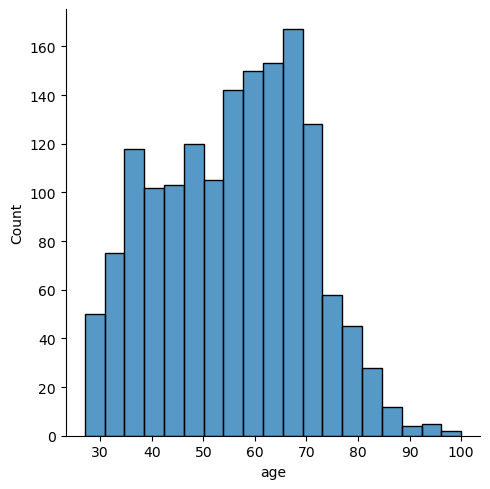

```python
sns.displot(data = pitt_df_clean, x = 'age', kind = 'hist')

plt.show()
```

By binning, we can take the missings into account as a categorical variable because we convert ages from continuous to categorical as well, defining them by their grouping rather than their value

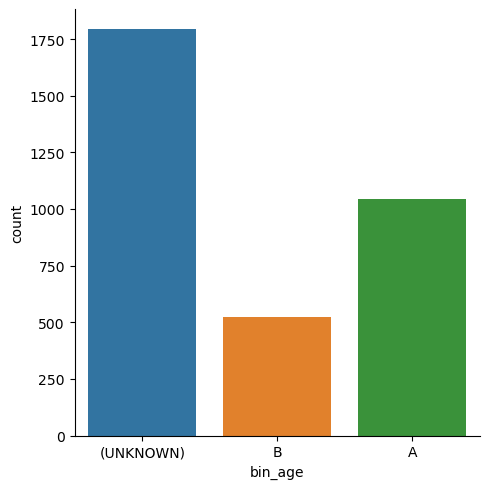

```python
pitt_df_clean['bin_age'] = pd.cut( pitt_df.age, bins=2, include_lowest=True, ordered=False, labels=['A', 'B'])
pitt_df_clean.bin_age = pitt_df_clean.bin_age.astype('object')
pitt_df_clean.bin_age.fillna(value='(UNKNOWN)', inplace=True)
sns.catplot(data = pitt_df_clean, x = 'bin_age', kind = 'count')
plt.show()
```

The same was done for `gender`

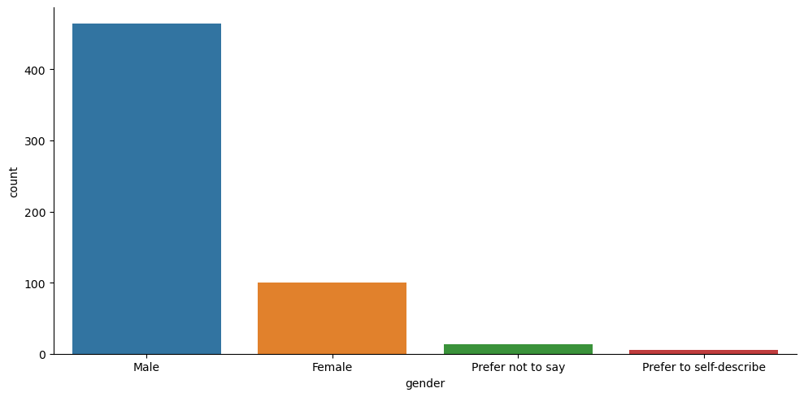

```python
sns.catplot(data = pitt_df, x = 'gender', kind = 'count', aspect = 2)

plt.show()
```

```python
pitt_df_clean.gender.value_counts(dropna=False)
```

```
gender
NaN                        2778
Male                        464
Female                      100
Prefer not to say            13
Prefer to self-describe       5
Name: count, dtype: int64
```

While the chart makes it look like the Male gender dominates, the highest "category" is actually the unknowns. Given the scale of the value counts, the bins were set to either "known" or "unknown" in terms of gender.

```python
pitt_df_clean.gender.fillna(value='(UNKNOWN)',inplace=True)
pitt_df_clean.gender.value_counts()
```

```
gender
(UNKNOWN)                  2778
Male                        464
Female                      100
Prefer not to say            13
Prefer to self-describe       5
Name: count, dtype: int64
```

```python
pitt_df_clean['gender_known'] = np.where(pitt_df_clean.gender == '(UNKNOWN)', pitt_df_clean.gender, '(KNOWN)')
```

```python
pitt_df_clean.gender_known.value_counts()
```

```
gender_known
(UNKNOWN)    2778
(KNOWN)       582
Name: count, dtype: int64
```

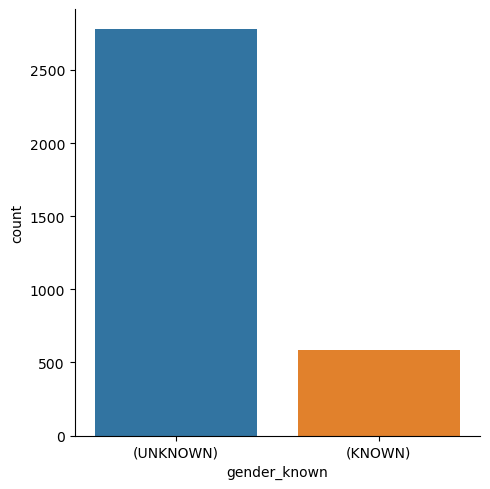

```python
sns.catplot(data = pitt_df_clean, x = 'gender_known', kind = 'count')

plt.show()
```

The 2 `peak_drivetime` columns were found to reflect the behavior of the `distancemiles` and `direction` variables, meaning that rather than trying to process their missing values, they could be excluded all-together as variables

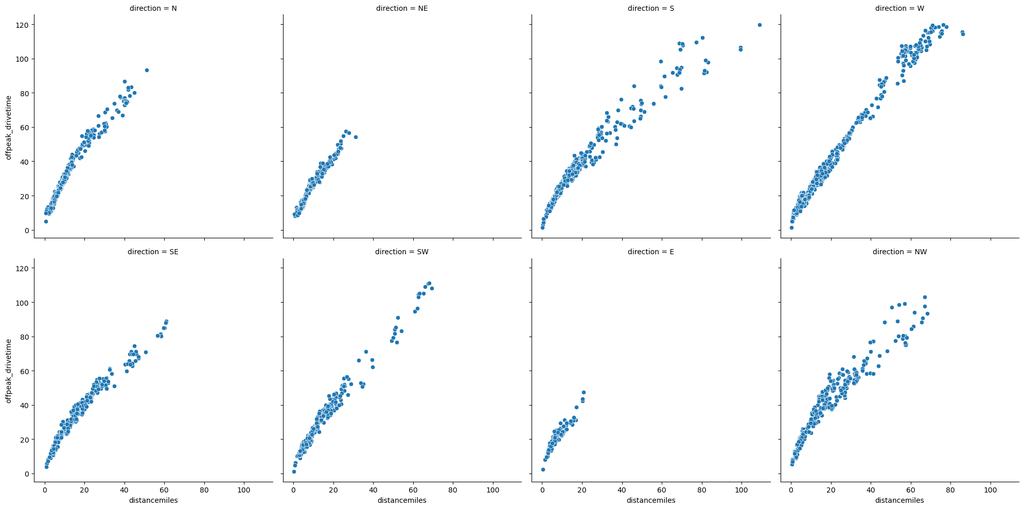

```python
sns.relplot(data = pitt_df, x='distancemiles', y='offpeak_drivetime', col='direction', col_wrap=4, kind='scatter')

plt.show()
```

Lastly to prepare our data for modeling, our results variable `return_next_season` needed to be converted into binary for classification

```python
pitt_df_clean['y'] = np.where( pitt_df.return_next_season == 'YES', 1, 0 )
```

```python
pitt_df_clean.info()
```

```
<class 'pandas.core.frame.DataFrame'>
RangeIndex: 3360 entries, 0 to 3359
Data columns (total 20 columns):
 #   Column              Non-Null Count  Dtype
---  ------              --------------  -----
 0   accountid           3360 non-null   int64
 1   age                 1567 non-null   float64
 2   gender              3360 non-null   object
 3   distancemiles       3360 non-null   float64
 4   direction           3360 non-null   object
 5   peak_drivetime      2958 non-null   float64
 6   offpeak_drivetime   2996 non-null   float64
 7   season              3360 non-null   int64
 8   purchase_month      3360 non-null   object
 9   purchase_dow        3360 non-null   object
 10  price_type          3360 non-null   object
 11  price_level         3360 non-null   object
 12  ticket_count        3360 non-null   int64
 13  price_per_ticket    3360 non-null   float64
 14  return_next_season  3360 non-null   object
 15  miles_log           3360 non-null   float64
 16  lump_ticket_count   3360 non-null   object
 17  bin_age             3360 non-null   object
 18  gender_known        3360 non-null   object
 19  y                   3360 non-null   int64
dtypes: float64(6), int64(4), object(10)
memory usage: 525.1+ KB
```

# Clustering

```python
pitt_df_cluster = pitt_df_clean.copy()
```

```python
pitt_df_cluster.accountid = pitt_df_cluster.accountid.astype('str')
pitt_df_cluster.season = pitt_df_cluster.season.astype('str')
```

```python
pitt_df_cluster.info()
```

```
<class 'pandas.core.frame.DataFrame'>
RangeIndex: 3360 entries, 0 to 3359
Data columns (total 20 columns):
 #   Column              Non-Null Count  Dtype
---  ------              --------------  -----
 0   accountid           3360 non-null   object
 1   age                 1567 non-null   float64
 2   gender              3360 non-null   object
 3   distancemiles       3360 non-null   float64
 4   direction           3360 non-null   object
 5   peak_drivetime      2958 non-null   float64
 6   offpeak_drivetime   2996 non-null   float64
 7   season              3360 non-null   object
 8   purchase_month      3360 non-null   object
 9   purchase_dow        3360 non-null   object
 10  price_type          3360 non-null   object
 11  price_level         3360 non-null   object
 12  ticket_count        3360 non-null   int64
 13  price_per_ticket    3360 non-null   float64
 14  return_next_season  3360 non-null   object
 15  miles_log           3360 non-null   float64
 16  lump_ticket_count   3360 non-null   object
 17  bin_age             3360 non-null   object
 18  gender_known        3360 non-null   object
 19  y                   3360 non-null   int64
dtypes: float64(6), int64(2), object(12)
memory usage: 525.1+ KB
```

```python
from sklearn.preprocessing import StandardScaler
from sklearn.cluster import KMeans
```

```python
KM_pitt_df = pitt_df_cluster.dropna().copy()
KM_pitt_df.info()
```

```
<class 'pandas.core.frame.DataFrame'>
Index: 1411 entries, 2 to 3359
Data columns (total 20 columns):
 #   Column              Non-Null Count  Dtype
---  ------              --------------  -----
 0   accountid           1411 non-null   object
 1   age                 1411 non-null   float64
 2   gender              1411 non-null   object
 3   distancemiles       1411 non-null   float64
 4   direction           1411 non-null   object
 5   peak_drivetime      1411 non-null   float64
 6   offpeak_drivetime   1411 non-null   float64
 7   season              1411 non-null   object
 8   purchase_month      1411 non-null   object
 9   purchase_dow        1411 non-null   object
 10  price_type          1411 non-null   object
 11  price_level         1411 non-null   object
 12  ticket_count        1411 non-null   int64
 13  price_per_ticket    1411 non-null   float64
 14  return_next_season  1411 non-null   object
 15  miles_log           1411 non-null   float64
 16  lump_ticket_count   1411 non-null   object
 17  bin_age             1411 non-null   object
 18  gender_known        1411 non-null   object
 19  y                   1411 non-null   int64
dtypes: float64(6), int64(2), object(12)
memory usage: 231.5+ KB
```

```python
pitt_numbers = KM_pitt_df.select_dtypes('number').copy()
X = StandardScaler().fit_transform(pitt_numbers)
```

In order to find the best number of clustersm we will use a kneebend plot

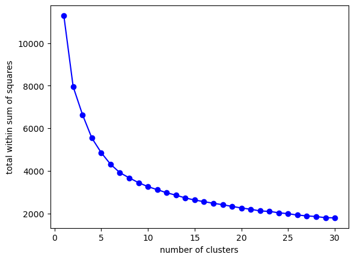

```python
tots_within = []

K = range(1, 31)

for k in K:
    km = KMeans(n_clusters=k, random_state=121, n_init=25, max_iter=500)
    km = km.fit( X )

    tots_within.append( km.inertia_ )

fig, ax = plt.subplots()

ax.plot( K, tots_within, 'bo-' )
ax.set_xlabel('number of clusters')
ax.set_ylabel('total within sum of squares')

plt.show()
```

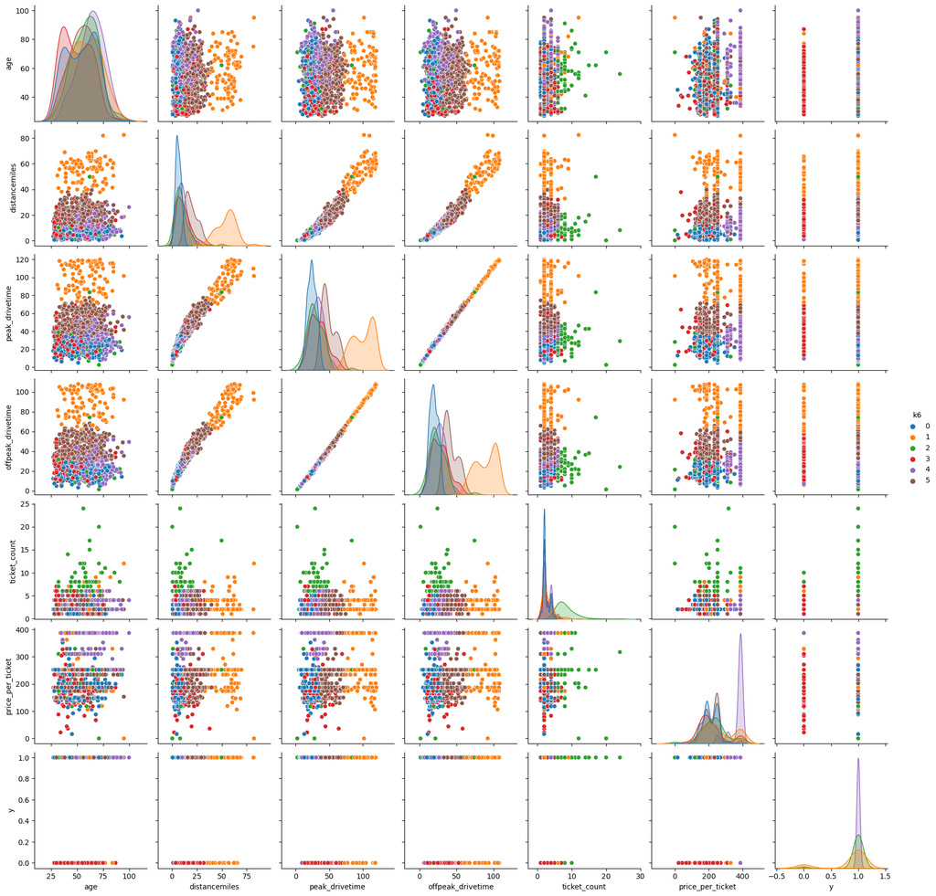

```python
pitt_clusters_6 = KMeans(n_clusters=6, random_state=121, n_init=25, max_iter=500).fit_predict(X)
KM_pitt_df['k6'] = pd.Series(pitt_clusters_6, index= KM_pitt_df.index).astype('category')

sns.pairplot(data = KM_pitt_df, hue = 'k6',vars=['age', 'distancemiles', 'peak_drivetime', 'offpeak_drivetime', 'ticket_count', 'price_per_ticket', 'y'],diag_kws={'common_norm':False})

plt.show()
```

Based on my analysis of this clustering, none of the continous inputs alone appear to give any indication as to wheter or not someone will renew their tickets or not as showin in the `y` column and row of this pairsplot

# Modeling

Here are the details of the formula I found to provide the best results as a model:

```python
best_model = 'y ~ (miles_log + price_per_ticket)**2 + np.power(miles_log, 2) + np.power(price_per_ticket, 2) * (gender_known + bin_age + direction + purchase_month + purchase_dow + price_type + price_level + lump_ticket_count)'
```

```python
best_fit = smf.logit(formula= best_model, data = pitt_df_clean).fit()
```

```
Optimization terminated successfully.
         Current function value: 0.450918
         Iterations 8
```

```python
def fit_and_assess_logistic(mod_name, a_formula, train_data, threshold):
    a_mod = smf.logit(formula=a_formula, data=train_data).fit()

    train_copy = train_data.copy()

    train_copy['pred_probability'] = a_mod.predict( train_data )

    train_copy['pred_class'] = np.where( train_copy.pred_probability > threshold, 1, 0 )

    TN, FP, FN, TP = confusion_matrix( train_copy.y.to_numpy(), train_copy.pred_class.to_numpy() ).ravel()

    Accuracy = (TN + TP) / (TN + FP + FN + TP)

    Sensitivity = (TP) / (TP + FN)

    Specificity = (TN) / (TN + FP)

    FPR = 1 - Specificity

    ROC_AUC = roc_auc_score( train_copy.y.to_numpy(), train_copy.pred_probability.to_numpy() )

    res_dict = {'model_name': mod_name,
                'model_formula': a_formula,
                'num_coefs': len( a_mod.params ),
                'threshold': threshold,
                'Accuracy': Accuracy,
                'Sensitivity': Sensitivity,
                'Specificity': Specificity,
                'FPR': FPR,
                'ROC_AUC': ROC_AUC}

    return pd.DataFrame( res_dict, index=[0] )
```

```python
formula_list = [#intercept
                'y ~ 1',
                # D.d.vi - interact categorical inputs with the continuous inputs and linear main effects
                'y ~ (gender_known + bin_age + direction + purchase_month + purchase_dow + price_type + price_level + lump_ticket_count) * (price_per_ticket + miles_log)',
                #just the continuous variables
                'y ~ miles_log + price_per_ticket',
                #All variables
                'y ~ gender_known + bin_age + direction + miles_log + purchase_month + purchase_dow + price_per_ticket + price_type + price_level + lump_ticket_count',
                #continous variables ** 2
                'y ~ (miles_log + price_per_ticket) ** 2',
                #just categorical variables
                'y ~ gender_known + bin_age + direction + purchase_month + purchase_dow + price_type + price_level + lump_ticket_count',
                # based on EDA
                'y ~ price_level + price_type + gender_known + purchase_month + bin_age',
                #Continuous with pair-wise interactions
                'y ~ miles_log * price_per_ticket',
                #Complex
                'y ~ (miles_log + price_per_ticket)**2 + np.power(miles_log, 2) + np.power(price_per_ticket, 2) * (gender_known + bin_age + direction + purchase_month + purchase_dow + price_type + price_level + lump_ticket_count)'
]
```

```python
results_list = []

for m in range(len(formula_list)):
    results_list.append( fit_and_assess_logistic(m, formula_list[m], train_data = pitt_df_clean, threshold=0.5) )
```

```
Optimization terminated successfully.
         Current function value: 0.637541
         Iterations 4
Optimization terminated successfully.
         Current function value: 0.446748
         Iterations 8
Optimization terminated successfully.
         Current function value: 0.598729
         Iterations 5
Optimization terminated successfully.
         Current function value: 0.463606
         Iterations 7
Optimization terminated successfully.
         Current function value: 0.595660
         Iterations 6
Optimization terminated successfully.
         Current function value: 0.477232
         Iterations 7
Optimization terminated successfully.
         Current function value: 0.487048
         Iterations 7
Optimization terminated successfully.
         Current function value: 0.595660
         Iterations 6
Optimization terminated successfully.
         Current function value: 0.450918
         Iterations 8
```

```python
results_df = pd.concat( results_list, ignore_index=True )
results_df
```

|  | model_name | model_formula | num_coefs | threshold | Accuracy | Sensitivity | Specificity | FPR | ROC_AUC |
| --- | --- | --- | --- | --- | --- | --- | --- | --- | --- |
| 0 | 0 | y ~ 1 | 1 | 0.5 | 0.665179 | 1.000000 | 0.000000 | 1.000000 | 0.500000 |
| 1 | 1 | y ~ (gender_known + bin_age + direction + purc... | 96 | 0.5 | 0.790774 | 0.896197 | 0.581333 | 0.418667 | 0.848604 |
| 2 | 2 | y ~ miles_log + price_per_ticket | 3 | 0.5 | 0.684524 | 0.941834 | 0.173333 | 0.826667 | 0.675988 |
| 3 | 3 | y ~ gender_known + bin_age + direction + miles... | 34 | 0.5 | 0.784821 | 0.896197 | 0.563556 | 0.436444 | 0.835287 |
| 4 | 4 | y ~ (miles_log + price_per_ticket) ** 2 | 4 | 0.5 | 0.691667 | 0.941387 | 0.195556 | 0.804444 | 0.679169 |
| 5 | 5 | y ~ gender_known + bin_age + direction + purch... | 32 | 0.5 | 0.769048 | 0.899329 | 0.510222 | 0.489778 | 0.823494 |
| 6 | 6 | y ~ price_level + price_type + gender_known + ... | 16 | 0.5 | 0.758929 | 0.912304 | 0.454222 | 0.545778 | 0.811221 |
| 7 | 7 | y ~ miles_log * price_per_ticket | 4 | 0.5 | 0.691667 | 0.941387 | 0.195556 | 0.804444 | 0.679169 |
| 8 | 8 | y ~ (miles_log + price_per_ticket)**2 + np.pow... | 68 | 0.5 | 0.794048 | 0.900224 | 0.583111 | 0.416889 | 0.845686 |

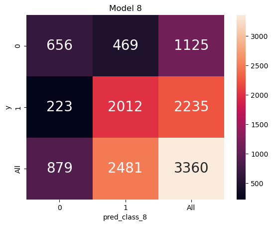

```python
df_model_copy = pitt_df_clean.copy()
df_model_copy['pred_prob_8'] = best_fit.predict(pitt_df_clean)

#Classify the training set
df_model_copy['pred_class_8'] = np.where( df_model_copy.pred_prob_8 > 0.5, 1, 0 )


fig, ax = plt.subplots()

sns.heatmap( pd.crosstab(df_model_copy.y, df_model_copy.pred_class_8, margins=True),
             annot=True, annot_kws={'size': 20}, fmt='3d' )

ax.set_title('Model 8')

plt.show()
```

```python
def my_coefplot(mod, figsize_use=(10,14)):
    fig, ax = plt.subplots(figsize = figsize_use)

    ax.errorbar( y=mod.params.index,
                 x=mod.params,
                 xerr = 2 * mod.bse,
                 fmt='o', color='k', ecolor='k', elinewidth=2, ms=10)

    ax.axvline(x=0, linestyle='--', linewidth=3.5, color='grey')

    ax.set_xlabel('coefficient value')

    plt.show()
```

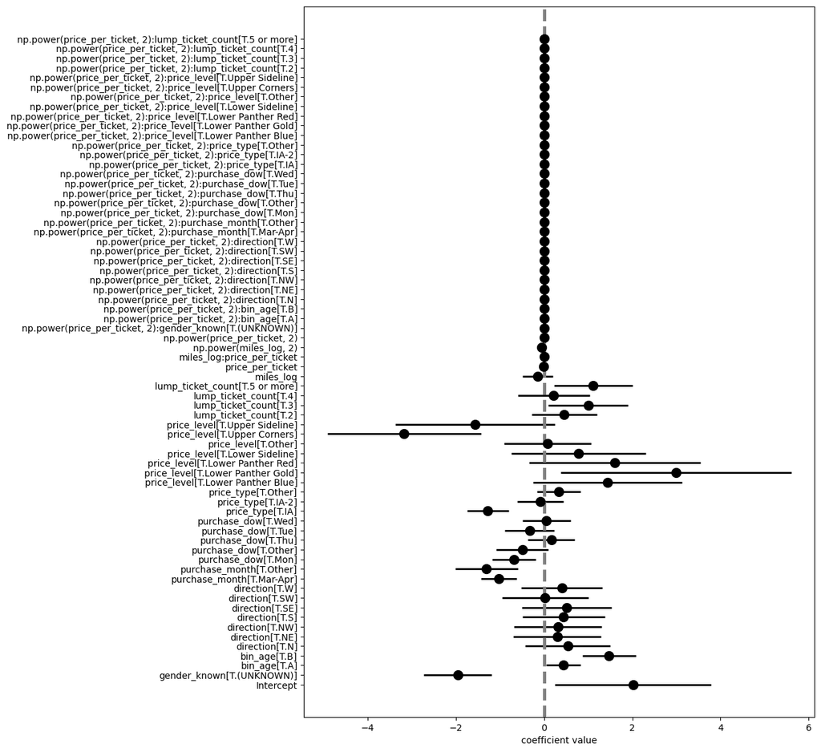

```python
my_coefplot(best_fit)
```

From this coefficient plot, I identified the variables of `price_level` and `gender_known`to be significant. In order to include a continuous variable, I included `log_miles` which showed more significance than the `price_per_ticket`

## Model Visualization

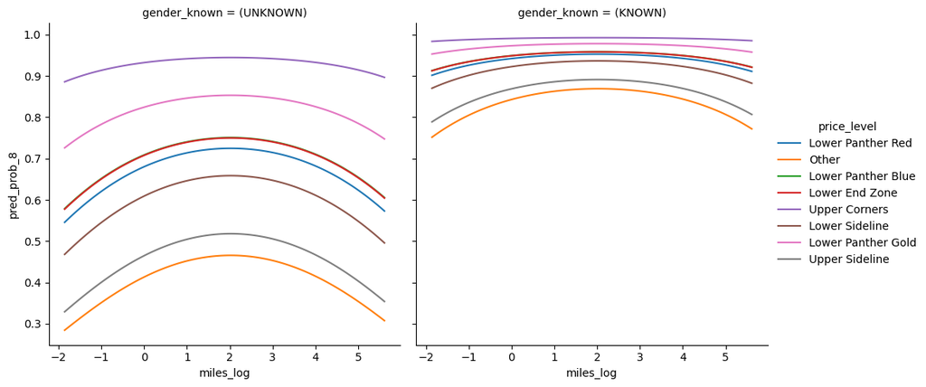

```python
input_grid_8 = pd.DataFrame([ (gender_known,
                             bin_age,
                             direction,
                             miles_log,
                             purchase_month,
                             purchase_dow,
                             price_per_ticket,
                             price_type,
                             price_level,
                             lump_ticket_count)
                             for gender_known in pitt_df_clean.gender_known.unique()
                             for bin_age in pitt_df_clean.bin_age.mode()
                             for direction in pitt_df_clean.direction.mode()
                             for miles_log in np.linspace(pitt_df_clean.miles_log.min(), pitt_df_clean.miles_log.max(), num = 101)
                             for purchase_month in pitt_df_clean.purchase_month.mode()
                             for purchase_dow in pitt_df_clean.purchase_dow.mode()
                             for price_per_ticket in [pitt_df_clean.price_per_ticket.mean()]
                             for price_type in pitt_df_clean.price_type.mode()
                             for price_level in pitt_df_clean.price_level.unique()
                             for lump_ticket_count in pitt_df_clean.lump_ticket_count.mode() ],
                          columns=['gender_known','bin_age', 'direction', 'miles_log', 'purchase_month', 'purchase_dow', 'price_per_ticket',
                                  'price_type', 'price_level', 'lump_ticket_count'])
df_viz_8 = input_grid_8.copy()
df_viz_8['pred_prob_8'] = best_fit.predict(input_grid_8)

sns.relplot(data = df_viz_8, x='miles_log', y='pred_prob_8', hue='price_level', col='gender_known',
            kind='line', estimator=None, units='price_level')

plt.show()
```

Looking at these charts, we can see that knowing the gender of a STH will greatly increase the probability that they will renew their season tickets. There is also some variation based on the price-level of said ticket, which is explored further below

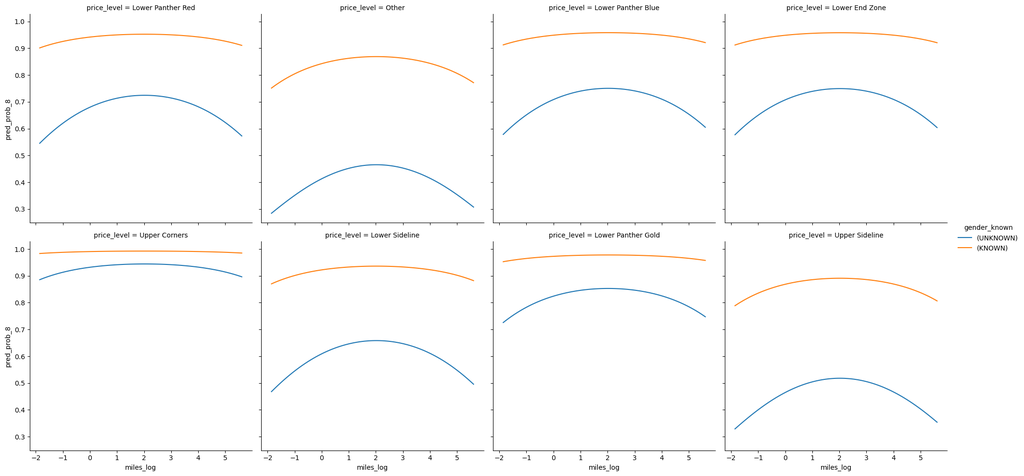

```python
sns.relplot(data = df_viz_8, x='miles_log', y='pred_prob_8', hue='gender_known', col='price_level',
            kind='line', estimator=None, units='gender_known', col_wrap=4)

plt.show()
```

While we continue to see that the known gender results in a higher chance of renewal, we can see that certain price levels such as "Upper Corners" and "Lower Panther Gold" have a much higher rate than "Upper Sideline" or "Other" even when the gender is known.

## Concluding Analysis

Based on the model that I formulated, I believe we can derive that the following variables play a key factor in whether or not a STH is likely to renew their tickets:

- knowing the gender of the STH
- the distance driven to the stadium
- the price level of the tickets

### "Could EDA help identify similar trends/relationships?"

When I look at a bar chart of the `price_level`counts, I see that the largest portion of renewals comes from the "Other" category (see below). Yet according to my model, "Other" has a lower chance of renewing than the named levels.

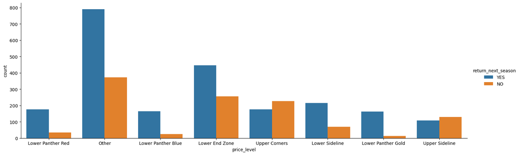

```python
sns.catplot(data = pitt_df_clean, x = 'price_level', kind = 'count', hue = 'return_next_season', aspect=3)

plt.show()
```

### "Was clustering consistent with any conclusions from the predictive models?"

No, the clustering was overarchingly unhelpful in this problem, most likely due to the overhwelming number of categorical variables, and the fact that we did not learn how to cluster by categorical variables in this course.

The other issue is that this dataset had missings to deal with, and since KMeans can't process missings, it limited the value it could bring to the analysis

### Final Thoughts/Takeaways

Overall I learned a lot from this project. I think some of the key takeaways are of course the backbone aspects of the project such as fitting models, measuring performance, and performing cross-validation. From a non-technical standpoint, I learned a lot about resourcefulness in data science. I had to parse through instructions that were often unclear due to being applicable to multiple different projects, and seek external resources to fill in the gaps of my knowledge.

This project is a 1:1 application for my future career goals, as I hope to one day work in professional sports. Being able to perform a task like this would provide clear benefits to an organization as they look for stategies for customer retention and outreach.